# act_report

## Report: act_report

- Create a **250-word-minimum written report** called "act_report.pdf" or "act_report.html" that communicates the insights and displays the visualization(s) produced from your wrangled data. This is to be framed as an external document, like a blog post or magazine article, for example.

This act report includes the summary of the Data Analysis process that was taken for the data wrangling project.

In this project, i worked with three data points merged into a single file 'twitter_archive_master.csv'

Datapoints:

1. twitter_archive_enhanced.csv: the document was provided by Udacity and it contains a sample data of 2356 rows.
2. image_prediction.tsv: this file was hosted on the Udacity server which i programmatically downloaded and clean. There were 2075 records
3. tweet-json.txt: This Twitter scraped file was provided by Udacity and it contains 2327 samples of Twitter data

While accessing the data, i discovered 9 quality issues and 2 tidiness issues which were taken care of to have clean data for analysis.

Here are some exciting insights i got from analysing the merged dataset 'twitter_archive_master.csv'

#### Insights

1. A total of 644 dogs have no name which accounts for 32% of the sample data
2. Tweet_id 744234799360020481 have the highest number of retweet (79515) and 666102155909144576 has the lowest number of retweet (16)
3. Tweet_id 822872901745569793 has the highest number of likes (132810) and 666102155909144576 the lowest number of likes (81)
4. The percentage of the dogs whose stage was not stated is 87.65%, indicating a total of 1688
5. Nine of the columns are object data types (string), one is DateTime, five are integer data types, three are floats, and the remaining three are boolean data types.

#### Visualization

1. The most occcuring image number that corresponds to each tweet's most confident prediction is 1.

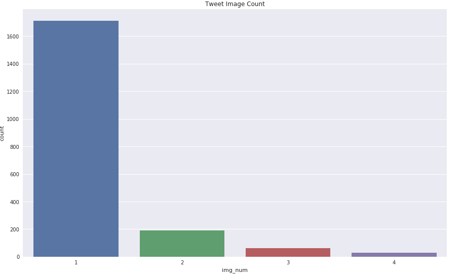

1. Pupper and Doggo have the higest number of popularity in the available dataset, 'None' category is not included because it depicts dog without stages

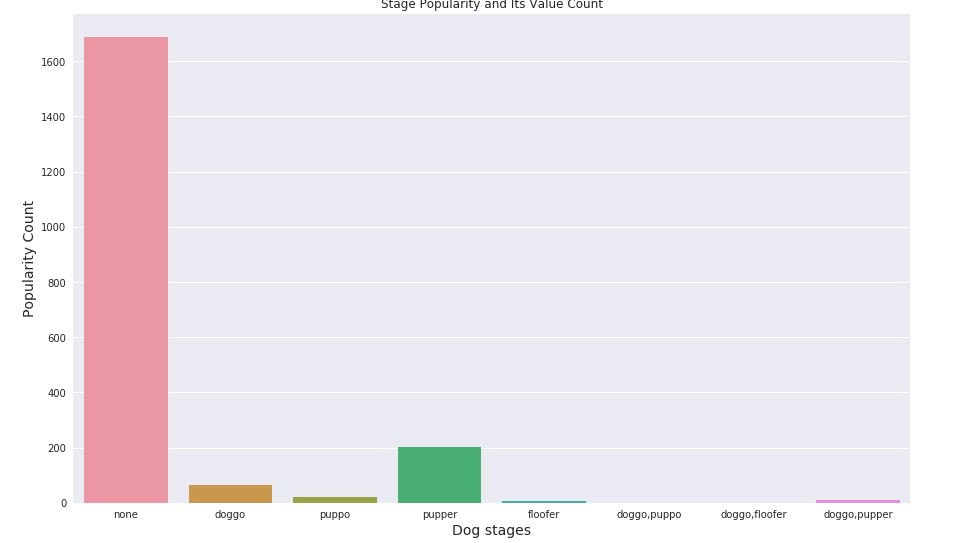